# RNA-seq Analysis in R

Annotation and Visualisation of RNA-seq results - INSTRUCTOR MATERIALS

Stephane Ballereau, Abbi Edwards, Ashley Sawle

Last modified: 21 May 2020

REMEMBER TO COMMENT AS YOU GO!!!!!!!! SETWD WITH GUI

```r
library(EnsDb.Mmusculus.v79)
library(DESeq2)
library(tidyverse)
```

Before starting this section, we will make sure we have all the relevant objects from the Differential Expression analysis.

```r
load("../Course_Materials/Robjects/DE.RData")
```

# Overview

- Annotation
- Visualising DE results

# Adding annotation to the DESeq2 results

VIEW resLvV

only see the Ensembl Gene ID, which is not very informative.

There are a number of ways to add annotation. The are R packages for this at an organism level which are updated every 6 months.

An alternative approach is to use `biomaRt`, an interface to the [BioMart](http://www.biomart.org/) resource.

## Set up our query

We use the select function to query the database. Now we need to set up a query. This requires us to tell it what we want and what we have. For this we need to specify three things:

1. What type of information we are going to search the dataset on - called **keytypes**. In our case this is Ensembl Gene IDs
2. A vector of the **keys** for our filter - the Ensembl Gene IDs from our DE results table
3. What columns (**columns**) of the dataset we want returned.

```r
# what can we search for? 'columns'
columns(EnsDb.Mmusculus.v79)
```

```
 [1] "ENTREZID"            "EXONID"              "EXONIDX"
 [4] "EXONSEQEND"          "EXONSEQSTART"        "GENEBIOTYPE"
 [7] "GENEID"              "GENENAME"            "GENESEQEND"
[10] "GENESEQSTART"        "INTERPROACCESSION"   "ISCIRCULAR"
[13] "PROTDOMEND"          "PROTDOMSTART"        "PROTEINDOMAINID"
[16] "PROTEINDOMAINSOURCE" "PROTEINID"           "PROTEINSEQUENCE"
[19] "SEQCOORDSYSTEM"      "SEQLENGTH"           "SEQNAME"
[22] "SEQSTRAND"           "SYMBOL"              "TXBIOTYPE"
[25] "TXCDSSEQEND"         "TXCDSSEQSTART"       "TXID"
[28] "TXNAME"              "TXSEQEND"            "TXSEQSTART"
[31] "UNIPROTDB"           "UNIPROTID"           "UNIPROTMAPPINGTYPE"
```

```r
# what can we search with? 'keytypes'
keytypes(EnsDb.Mmusculus.v79)
```

```
 [1] "ENTREZID"            "EXONID"              "GENEBIOTYPE"
 [4] "GENEID"              "GENENAME"            "PROTDOMID"
 [7] "PROTEINDOMAINID"     "PROTEINDOMAINSOURCE" "PROTEINID"
[10] "SEQNAME"             "SEQSTRAND"           "SYMBOL"
[13] "TXBIOTYPE"           "TXID"                "TXNAME"
[16] "UNIPROTID"
```

```r
# lets set it up
ourCols <- c("SYMBOL", "GENEID", "ENTREZID")
ourKeys <- rownames(resLvV)[1:1000]

# run the query
annot <- AnnotationDbi::select(EnsDb.Mmusculus.v79,
                keys=ourKeys,
                columns=ourCols,
                keytype="GENEID")
```

### One-to-many relationships

Let’s inspect the annotation.

```r
head(annot)
```

|  | SYMBOL | GENEID | ENTREZID |
| --- | --- | --- | --- |
| 1 | Xkr4 | ENSMUSG00000051951 | 497097 |
| 2 | RP23-122M2.3 | ENSMUSG00000102331 | NA |
| 3 | Rp1 | ENSMUSG00000025900 | 19888 |
| 4 | Sox17 | ENSMUSG00000025902 | 20671 |
| 5 | Gm6085 | ENSMUSG00000098104 | NA |
| 6 | RP23-34E15.4 | ENSMUSG00000103922 | NA |

```r
length(unique(annot$ENTREZID)) # Why are there NAs in the ENTREZID column?
```

```
[1] 533
```

```r
dim(annot) # why are there more than 1000 rows?
```

```
[1] 1010    3
```

```r
# find all rows containing duplicated ensembl ids
annot %>%
    add_count(GENEID) %>%
    dplyr::filter(n>1)
```

| SYMBOL | GENEID | ENTREZID | n |
| --- | --- | --- | --- |
| Tceb1 | ENSMUSG00000079658 | 67923 | 2 |
| Tceb1 | ENSMUSG00000079658 | 102642819 | 2 |
| Ptp4a1 | ENSMUSG00000026064 | 19243 | 2 |
| Ptp4a1 | ENSMUSG00000026064 | 102643131 | 2 |
| Cox5b | ENSMUSG00000061518 | 12859 | 3 |
| Cox5b | ENSMUSG00000061518 | 102638382 | 3 |
| Cox5b | ENSMUSG00000061518 | 102641600 | 3 |
| Rpl31 | ENSMUSG00000073702 | 665562 | 2 |
| Rpl31 | ENSMUSG00000073702 | 102641215 | 2 |
| Hspd1 | ENSMUSG00000025980 | 15510 | 2 |

[output cut: 20 more lines]

```r
NA
```

There are a couple of genes that have multiple entries in the retrieved annotation. This is becaues there are multiple Entrez IDs for a single Ensembl gene. These one-to-many relationships come up frequently in genomic databases, it is important to be aware of them and check when necessary.

We will need to do a little work before adding the annotation to out results table. We could decide to discard one or both of the Entrez ID mappings, or we could concatenate the Entrez IDs so that we don’t lose information.

this illustrates how/why annotation is complicated and difficult

## Retrieve full annotation

### Challenge 1

> A reminder of the code we ran:

```
# lets set it up
ourCols <- c("SYMBOL", "GENEID", "ENTREZID")
ourKeys <- rownames(resLvV)[1:1000]

# run the query
annot <- AnnotationDbi::select(EnsDb.Mmusculus.v79,
                keys=ourKeys,
                columns=ourCols,
                keytype="GENEID")
```

> That was just 1000 genes. We need annotations for the entire results table.
> 1. Run the same query using all of the genes in our results table (`resLvV`)
> 2. Can we also have the biotype of our genes too? Hint: You can find the name of the column for this by running columns(EnsDb.Mmusculus.v79)
> 3. How many Ensembl genes have multipe Entrez IDs associated with them?

```r
# lets set it up
ourCols <- c("SYMBOL", "GENEID", "ENTREZID", "GENEBIOTYPE")
ourKeys <- rownames(resLvV)

# run the query
annot <-AnnotationDbi::select(EnsDb.Mmusculus.v79,
                keys=ourKeys,
                columns=ourCols,
                keytype="GENEID")
# multiple EntrezIDs
multiples <- annot %>%
  add_count(GENEID) %>%
  dplyr::filter(n>1)

length(unique(multiples$SYMBOL))
```

[output not shown]

### Add annotation to the results table

- we have created an annotation table:
  - modified the column names
  - added median transcript length
  - dealt with the one-to-many issues for Entrez IDs.

```r
load("../Course_Materials/Robjects/Ensembl_annotations.RData")
colnames(ensemblAnnot)
```

```
 [1] "GeneID"         "Entrez"         "Symbol"         "Description"
 [5] "Biotype"        "Chr"            "Start"          "End"
 [9] "Strand"         "medianTxLength"
```

```r
annotLvV <- as.data.frame(resLvV) %>%
    rownames_to_column("GeneID") %>%
    left_join(ensemblAnnot, "GeneID") %>%
    rename(logFC=log2FoldChange, FDR=padj)
```

Finally we can output the annotation DE results using `write_tsv`.

```r
write_tsv(annotLvV, "../Course_Materials/data/VirginVsLactating_Results_Annotated.txt")
```

have to a look and see if genes make biological sense

```r
annotLvV %>%
    arrange(FDR) %>%
    head(10)
```

|  | GeneID | baseMean | logFC | lfcSE | stat | pvalue | FDR | Entrez | Symbol | Description | Biotype | Chr | Start | End | Strand | medianTxLength |
| --- | --- | --- | --- | --- | --- | --- | --- | --- | --- | --- | --- | --- | --- | --- | --- | --- |
| 1 | ENSMUSG00000000381 | 384010.7324 | 9.887948 | 0.4218050 | 23.44199 | 1.595680e-121 | 3.263165e-117 | 22373 | Wap | whey acidic protein [Source:MGI Symbol;Acc:MGI:98943] | protein_coding | 11 | 6635482 | 6638637 | -1 | 551.0 |
| 2 | ENSMUSG00000061937 | 1154100.0043 | 8.283917 | 0.4205029 | 19.70003 | 2.155119e-86 | 2.203609e-82 | 12993 | Csn1s2a | casein alpha s2-like A [Source:MGI Symbol;Acc:MGI:88542] | protein_coding | 5 | 87774567 | 87788797 | 1 | 752.0 |
| 3 | ENSMUSG00000061388 | 30887.6968 | 10.559509 | 0.5637298 | 18.73151 | 2.740361e-78 | 1.868013e-74 | 12992 | Csn1s2b | casein alpha s2-like B [Source:MGI Symbol;Acc:MGI:105312] | protein_coding | 5 | 87808082 | 87824426 | 1 | 810.0 |
| 4 | ENSMUSG00000022491 | 516162.0093 | 9.648553 | 0.5350069 | 18.03445 | 1.045396e-72 | 5.344587e-69 | 14663 | Glycam1 | glycosylation dependent cell adhesion molecule 1 [Source:MGI Symbol;Acc:MGI:95759] | protein_coding | 15 | 103562759 | 103565081 | -1 | 634.5 |
| 5 | ENSMUSG00000026417 | 11185.5610 | 6.432567 | 0.3684284 | 17.45948 | 2.915846e-68 | 1.192581e-64 | 18703 | Pigr | polymeric immunoglobulin receptor [Source:MGI Symbol;Acc:MGI:103080] | protein_coding | 1 | 130826684 | 130852249 | 1 | 784.0 |
| 6 | ENSMUSG00000024903 | 58185.3047 | 8.780796 | 0.5381186 | 16.31758 | 7.400730e-60 | 2.522415e-56 | 100470 | Lao1 | L-amino acid oxidase 1 [Source:MGI Symbol;Acc:MGI:2140628] | protein_coding | 4 | 118961578 | 118968912 | 1 | 1573.5 |
| 7 | ENSMUSG00000041417 | 7173.2887 | 1.550320 | 0.1009175 | 15.36225 | 2.932380e-53 | 8.566739e-50 | 18708 | Pik3r1 | phosphoinositide-3-kinase regulatory subunit 1 [Source:MGI Symbol;Acc:MGI:97583] | protein_coding | 13 | 101680563 | 101768217 | -1 | 701.0 |
| 8 | ENSMUSG00000029413 | 308.1040 | 2.244270 | 0.1493780 | 15.02410 | 5.104923e-51 | 1.304946e-47 | 67111 | Naaa | N-acylethanolamine acid amidase [Source:MGI Symbol;Acc:MGI:1914361] | protein_coding | 5 | 92257659 | 92278170 | -1 | 1629.0 |
| 9 | ENSMUSG00000024331 | 270.9901 | -2.548520 | 0.1753719 | -14.53209 | 7.587250e-48 | 1.723992e-44 | 13506 | Dsc2 | desmocollin 2 [Source:MGI Symbol;Acc:MGI:103221] | protein_coding | 18 | 20030633 | 20059554 | -1 | 4141.0 |
| 10 | ENSMUSG00000005672 | 1833.4692 | -3.639336 | 0.2520588 | -14.43844 | 2.964660e-47 | 6.062730e-44 | 16590 | Kit | KIT proto-oncogene receptor tyrosine kinase [Source:MGI Symbol;Acc:MGI:96677] | protein_coding | 5 | 75574916 | 75656722 | 1 | 1973.0 |

# Visualisation

- `DESeq2` provides a functon called `lfcShrink` that shrinks log-Fold Change (LFC) estimates towards zero
- genes with low counts and high FC appear be much more significant than they are.
- The `lfcShrink` method compensates for this and allows better visualisation and ranking of genes.

```r
ddsShrink <- lfcShrink(ddsObj, coef="Status_lactate_vs_virgin")
```

```
using 'apeglm' for LFC shrinkage. If used in published research, please cite:
    Zhu, A., Ibrahim, J.G., Love, M.I. (2018) Heavy-tailed prior distributions for
    sequence count data: removing the noise and preserving large differences.
    Bioinformatics. https://doi.org/10.1093/bioinformatics/bty895
```

```r
shrinkLvV <- as.data.frame(ddsShrink) %>%
    rownames_to_column("GeneID") %>%
    left_join(ensemblAnnot, "GeneID") %>%
    rename(logFC=log2FoldChange, FDR=padj)
```

## P-value histogram

A quick and easy “sanity check” for our DE results is to generate a p-value histogram. Refer to Dom’s lecture yesterday.

Go to menti.com 86 66 47

What we should see is a high bar in the `0 - 0.05` and then a roughly uniform tail to the right of this.

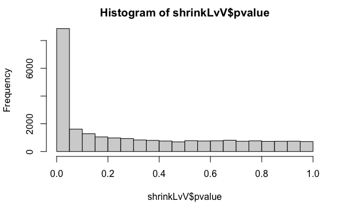

```r
hist(shrinkLvV$pvalue)
```

## MA plots

MA plots are a common way to visualize the results of a differential analysis. We met them briefly towards the end of Session 2 yesterday.

This plot shows the log-Fold Change against expression but remember its a mean across all the samples

`DESeq2` has a handy function for plotting this…

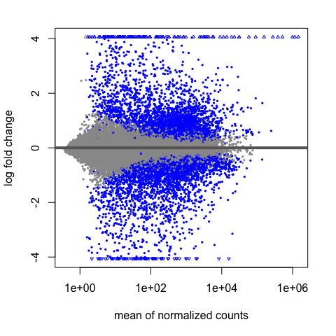

```r
plotMA(ddsShrink, alpha=0.05)
```

### A Brief Introduction to `ggplot2`

In brief:-

- `shrinkLvV` is our data frame containing the variables we wish to plot
- `aes` creates a mapping between the variables in our data frame to the *aes*thetic proprties of the plot:
  - the x-axis will be mapped to log2(`baseMean`)
  - the y-axis will be mapped to the `logFC`
- `geom_point` specifies the particular type of plot we want (in this case a scatter plot)
- `geom_text` allows us to add labels to some or all of the points
  - see [the cheatsheet](https://www.rstudio.com/wp-content/uploads/2015/03/ggplot2-cheatsheet.pdf) for other plot types

we can add metadata from the `sampleinfo` table to the data. The colours are automatically chosen by `ggplot2`, but we can specifiy particular values if we want.

Say we want to add top 10 most sig expressed genes to graph at labels, simplest way is to make an extra column with just those values in.

GO RIDICULOUSLY SLOWLY they are layers

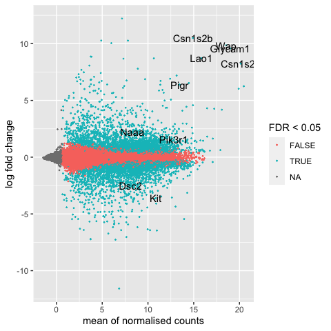

```r
# add a column with the names of only the top 10 genes
cutoff <- sort(shrinkLvV$pvalue)[10]
shrinkLvV <- shrinkLvV %>%
    mutate(TopGeneLabel=ifelse(pvalue<=cutoff, Symbol, ""))

ggplot(shrinkLvV, aes(x = log2(baseMean), y=logFC)) +
    geom_point(aes(colour=FDR < 0.05), shape=20, size=0.5) +
    geom_text(aes(label=TopGeneLabel)) +
    labs(x="mean of normalised counts", y="log fold change")
```

## Volcano plot

### Challenge 2

If you haven’t already make sure you load in our data and annotation. Then shrink the values. You can copy and paste the code below.

```
# First load data and annotations
load("../Robjects/DE.RData")
load("../Robjects/Ensembl_annotations.RData")

#Shrink our values
ddsShrink <- lfcShrink(ddsObj, coef="Status_lactate_vs_virgin")
shrinkLvV <- as.data.frame(ddsShrink) %>%
    rownames_to_column("GeneID") %>%
    left_join(ensemblAnnot, "GeneID") %>%
    rename(logFC=log2FoldChange, FDR=padj)
```

An example of what your plot should look like:

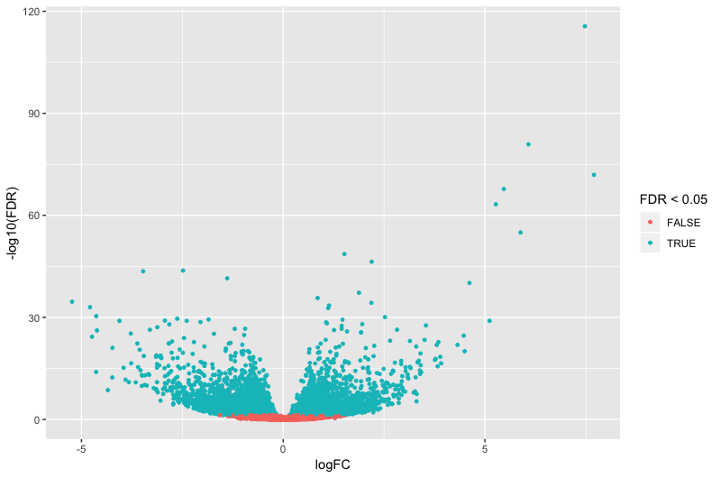

```r
# First load data and annotations
load("../Course_Materials/Robjects/DE.RData")
load("../Course_Materials/Robjects/Ensembl_annotations.RData")

#Shrink our values
ddsShrink <- lfcShrink(ddsObj, coef="Status_lactate_vs_virgin")
```

```
using 'apeglm' for LFC shrinkage. If used in published research, please cite:
    Zhu, A., Ibrahim, J.G., Love, M.I. (2018) Heavy-tailed prior distributions for
    sequence count data: removing the noise and preserving large differences.
    Bioinformatics. https://doi.org/10.1093/bioinformatics/bty895
```

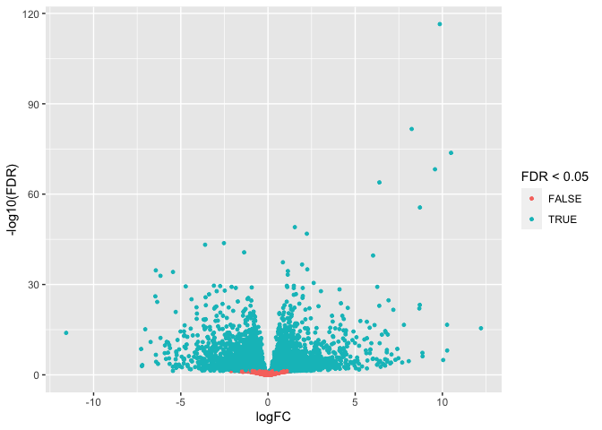

```r
shrinkLvV <- as.data.frame(ddsShrink) %>%
    rownames_to_column("GeneID") %>%
    left_join(ensemblAnnot, "GeneID") %>%
    rename(logFC=log2FoldChange, FDR=padj)

# first remove the filtered genes (FDR=NA) and create a -log10(FDR) column
filtTab <- shrinkLvV %>%
    filter(!is.na(FDR)) %>%
    mutate(`-log10(FDR)` = -log10(FDR))

ggplot(filtTab, aes(x = logFC, y=`-log10(FDR)`)) +
    geom_point(aes(colour=FDR < 0.05), size=1)
```

## Heatmap

We’re going to use the package `ComplexHeatmap` [@Gu2016]. We’ll also use `circlize` to generate a colour scale [@Gu2014].

```r
library(ComplexHeatmap)
library(circlize)
```

We can’t plot the entire data set, let’s just select the top 150 by FDR. We’ll also z-transform the counts.

wt means weight, - for reverse order

Stephane mentioned rlog yesterday, use vst today both avaliable with Deseq2, best to check manual to get exact differences for plotting the differences are subtle so just use vst because its faster

```r
# get the top genes
sigGenes <- as.data.frame(shrinkLvV) %>%
    top_n(150, wt=-FDR) %>%
    pull("GeneID")

# filter the data for the top 200 by padj in the LRT test
plotDat <- vst(ddsObj)[sigGenes,] %>%
    assay()
z.mat <- t(scale(t(plotDat), center=TRUE, scale=TRUE))
```

- assay pulls out the counts
- z.mat the z-score matrix
- yesterday we used heatmap2 which calculates these automatically for us, for complex heatmap we do it manually
- z- score is fc centred around zero and scaled
- the funtion ‘scale’ creates the z score for us but it expects data in the opposite orientation so we have to do a couple of transformations to make it work.

skew the scale for us, limits everything outside the myRamp to the truest colour so the small numbers in the middle don’t just end up white with no difference.

```r
# colour palette
myPalette <- c("red3", "ivory", "blue3")
myRamp = colorRamp2(c(-2, 0, 2), myPalette)
```

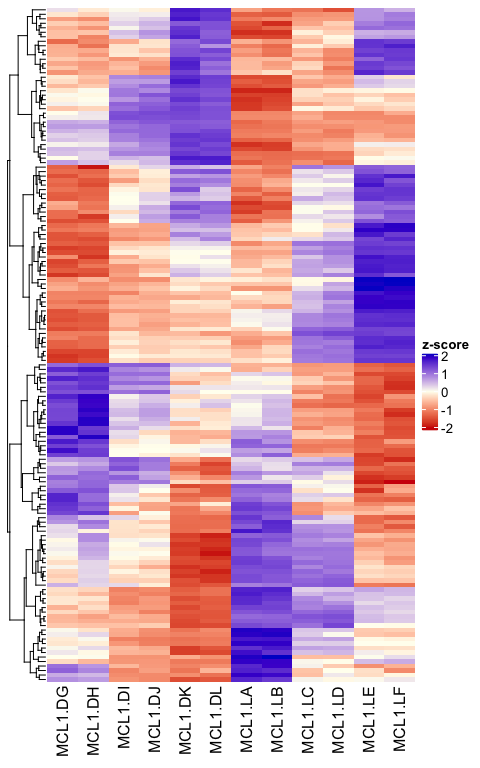

```r
Heatmap(z.mat, name = "z-score",
        col = myRamp,
        show_row_names = FALSE,
        cluster_columns = FALSE)
```

we can also split the heat map into clusters and add some annotation.

hclust generates the same tree we see on the left of our heatmap.

we have to decide at which level we want to cut the tree, 1 is lowest level

ha1 where we get annotation from

rect_gp is grey rectangle around each block lwd is line weight

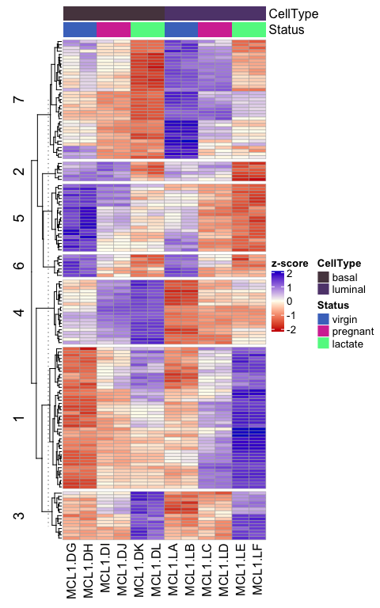

```r
# cluster the data and split the tree
hcDat <- hclust(dist(z.mat))
cutGroups <- cutree(hcDat, h=4)

ha1 = HeatmapAnnotation(df = colData(ddsObj)[,c("CellType", "Status")])

Heatmap(z.mat, name = "z-score",
        col = myRamp,
        show_row_name = FALSE,
        cluster_columns = FALSE,
        split=cutGroups,
        rect_gp = gpar(col = "darkgrey", lwd=0.5),
        top_annotation = ha1)
```

```r
save(annotLvV, shrinkLvV, file="../Course_Materials/results/Annotated_Results_LvV.RData")
```